# Entreprise Telco :

## K-Means

Le recours à la méthode K-means qui est un algorithme d’agrégation autour des centres mobiles. Cet algorithme débute avec un choix arbitraire des centres de classe et ensuite affecter chaque individu selon sa proximité au centre le plus proche.

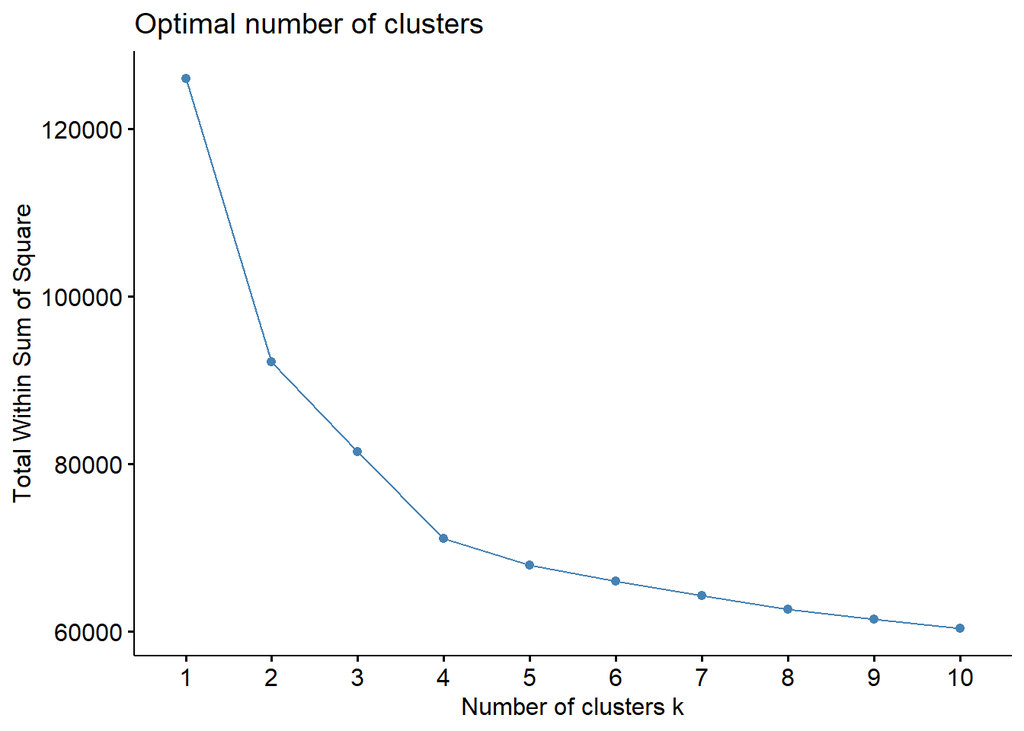

```r
set.seed(496)
dmy2 <- dummyVars(" ~ .", data = tab.kNN)
dmy2 <- data.frame(predict(dmy2, newdata = tab.kNN))
dmy2$"Churn"=NULL
dmy2 <- dmy2[1:3000,]

dta.cr <- scale(dmy2)

d.dta <- dist(dta.cr)

## Detection du nombre optimal de classes
## Avec factoextra
fviz_nbclust(dta.cr, hcut, method = "wss") #1er output
```

1er output: Le graphique qui présente le nombre optimal des classes indique la variabilité intra ou within qui décroit avec le nombre de classes. On voit que la courbe est relativement coudée au niveau de nombre de classes 4, ce qui indique que le nombre optimal est quatre classes. Ainsi, la CAH ainsi que la méthode K-means s’accordent sur le nombre de classes.

```r
set.seed(496)
## CAH
cah.ward <- hclust(d.dta,method="ward.D2")
cah.ward
```

```
##
## Call:
## hclust(d = d.dta, method = "ward.D2")
##
## Cluster method   : ward.D2
## Distance         : euclidean
## Number of objects: 3000
```

```r
set.seed(496)
groupes.cah <- cutree(cah.ward,k=4) ## Couper le dendrogramme en 4 groupes comme vu sur le graphique précédent

#K-Means
groupes.kmeans <- kmeans(d.dta,centers=4,nstart=5)
head(groupes.kmeans$cluster,20)
```

```
## 7590-VHVEG 5575-GNVDE 3668-QPYBK 7795-CFOCW 9237-HQITU 9305-CDSKC 1452-KIOVK
##          1          2          2          1          2          2          2
## 6713-OKOMC 7892-POOKP 6388-TABGU 9763-GRSKD 7469-LKBCI 8091-TTVAX 0280-XJGEX
##          1          3          2          2          4          3          3
## 5129-JLPIS 3655-SNQYZ 8191-XWSZG 9959-WOFKT 4190-MFLUW 4183-MYFRB
##          3          3          4          3          2          2
```

```r
## Correspondance avec les groupes de la CAH

print(table(groupes.cah,groupes.kmeans$cluster)) #2ème output
```

```
##
## groupes.cah    1    2    3    4
##           1  269    0    0    0
##           2    0 1146  190    0
##           3    0   39  705    0
##           4    0    0    0  651
```

2eme output: La classification selon cette méthode montre une part de l’inertie between dans l’inertie totale qui représente environ 77%. D’ailleurs, le graphique où on a mis en abscisses le nombre de classes et en ordonnées, la part de l’inertie expliquée montre que l’augmentation de cette part d’inertie expliquée s’accroit fortement quand passe d’une classe à deux, mais s’affaiblit quand le nombre de classes augmente. On peut remarquer qu’à partir de la classe 4, la hausse de l’inertie expliquée commence à s’accroitre encore d’une façon très modeste. Ceci corrobore le choix de quatre classes.

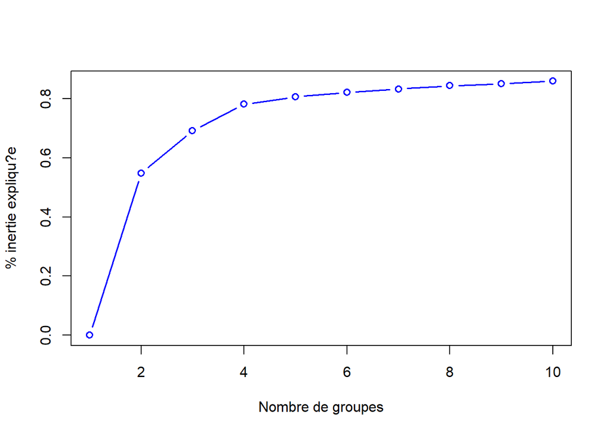

```r
## Evaluer la proportion d'inertie expliqu?e
inertie.expl <- rep(0,times=10)
for (k in 2:10){
  clus <- kmeans(d.dta,centers=k,nstart=5)
  inertie.expl[k] <- clus$betweenss/clus$totss
}

#graphique de l'inertie expliquée (3ème output)
plot(1:10,inertie.expl,type="b",xlab="Nombre de groupes",
     ylab="% inertie expliqu?e", col="blue", lwd=1.5)
```

# Apprentissage supervisé

## Préparation des données

Nous séparons ici notre base de donées en divers jeu. Il nous faut ici au minimum une base de test et une base d’entraînement. Une base d’entraînement sur laquel le modele va s’entrainer et une base de test pour voir la qualité de notre modèle.

```r
set.seed(496)
dmy <-tab.kNN
rownames(dmy) <- dmy$customerID
dmy$'customerID' <-  NULL
dmy <- dummyVars(" ~ .", data = dmy)
dmy <- data.frame(predict(dmy, newdata = tab.kNN))

ind=createDataPartition(dmy$Churn,times=1,p=0.8,list=FALSE)

train_val=dmy[ind,]
test_val=dmy[-ind,]
X_train=train_val[,-43]
y_train=as.factor(train_val[,43])
X_test=test_val[,-43]
y_test=as.factor(test_val[,43])

train_val2=train_val[,c("tenure","TotalCharges","MonthlyCharges","Contract.Month.to.month","Contract.Two.year","TechSupport.No","InternetService.DSL","InternetService.Fiber.optic","gender","Contract.Two.year","Partner","OnlineBackup.No","OnlineSecurity.No","PaperlessBilling","PaymentMethod.Electronic.check","nb_services","Contract.One.year","Churn")]

test_val2=test_val[,c("tenure","TotalCharges","MonthlyCharges", "Contract.Month.to.month","Contract.Two.year","TechSupport.No","InternetService.DSL","InternetService.Fiber.optic","gender","Contract.Two.year","Partner","OnlineBackup.No","OnlineSecurity.No","PaperlessBilling","PaymentMethod.Electronic.check","nb_services","Contract.One.year","Churn")]
X_train2=train_val2[,-18]
y_train2=as.factor(train_val2[,18])
X_test2=test_val2[,-18]
y_test2=as.factor(test_val2[,18])
```

## Abre de décision

L’objectif de notre arbre de décision est donc de classer les clients en 2 classes en fonction de leur churn ou non. A chaque étape, l’algorithme va chercher le critère permettant de séparer au mieux ces deux populations. Il existe plusieurs critères de séparation, dans notre exemple nous allons utiliser l’indice de Gini qui est utilisé pour les arbres CART

Pour construire notre arbre de décision, nous allons utiliser la commande rpart. Nous avons vu dans le cours, certains des paramètres adaptés à notre situation : nous avons ici la method qui est de type “class” car nous somme dans une situation ou la target est binaire; nous avons le paramètre minsplit qui est fixé à 5, c’est-à-dire que l’abre continuera à séparer les données tant que l’abre contiendra au moins 5 données. Enfin le paramètre CP est indicateur d’amélioration du modèle, si celui-ci est fixé a 0 alors le découpage à quand même lieu même si celui-ci n’améliore pas le modèle.

[figure not shown]

```r
set.seed(496)
#Construction de l'arbre
class.churn <- rpart(Churn~., data=train_val, method="class",control= rpart.control(minsplit=5,cp=0))
#affichage du résultat
plot(class.churn , uniform=TRUE, branch =0.5, margin =0.1)
text(class.churn, all=FALSE, use.n=TRUE)
```

Résultat: Nous avons ici un arbre illisible dont il nous est impossible de tirer la moindre conclusion. Il est beaucoup trop développé et nécessite un élagage afin de le simplifier et pour éviter surtout le surapprentissage.

L’élagage fonctionne par niveau, nous devons tout d’abord le fixer. Pour cela, nous créons un graph qui nous permettra de visualiser le taux de mauvais classement en fonction de la complexité paramètrée (CP). On pourra ainsi minimiser l’erreur pour un complexité donnée.

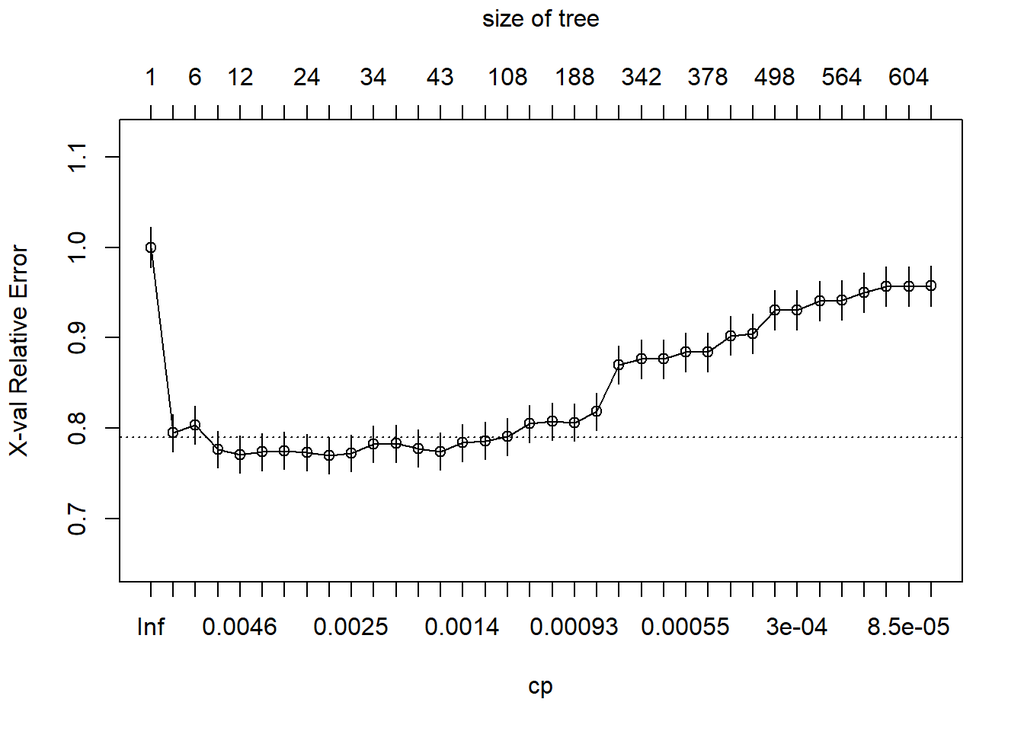

```r
set.seed(496)
#On cherche a minimier l'erreur pour definir le niveau d'élagage
plotcp(class.churn)
```

```r
#Affichage du cp optimal
print(class.churn$cptable[which.min(class.churn$cptable[,4]),1])
```

```
## [1] 0.002710027
```

```r
#Elagage de l'arbre avec le CP optimal
set.seed(496)
class.churn_Opt <- prune(class.churn, cp=class.churn$cptable[which.min(class.churn$cptable[,4]),1])
```

Il ne nous reste maintenant plus qu’à représenter ce nouvel arbre avec la complexité optimale. L’arbre reste encore assez compliqué à lire sur la console R mais les règles de construction de l’arbre sont, elles, beaucoup plus simples, chaque ligne y représente une feuille. On peut voir qu’à la première étape, l’algorithme prend tous les individus et recherche la variables qui sépare le mieux les individus en 2 populations. La variable est sélectionnée selon le critère de l’indice de Gini. Plus celui-ci sera élevé, mieux le découpage sera. Chacun de ces découpages conduit à diviser l’échantillon en deux populations de part leurs facteurs discriminants les plus marquants.

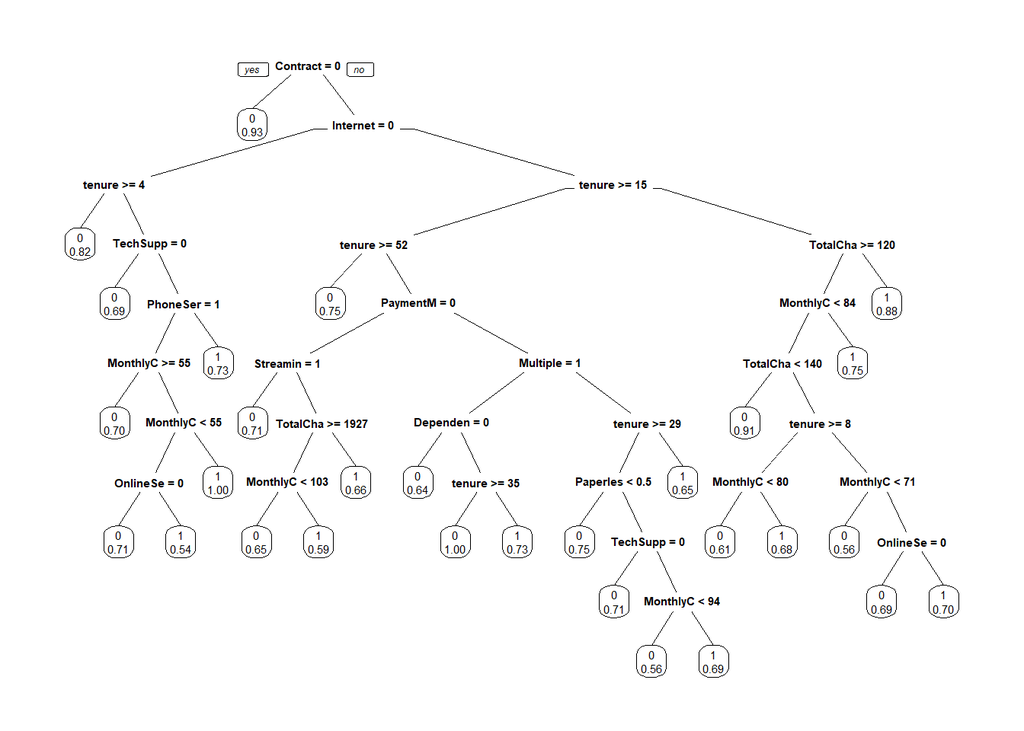

```r
set.seed(496)
#Représentation graphique de l'arbre optimal
prp(class.churn_Opt, extra=8)
```